# Lab 03 - Data visualization 1

Kyunghee Lee

Below is the code we use from the lecture, plus some exercise questions. The RMD file is on `Code` tab on the top. You can either `Knit` the entire document to produce a html doc, `Run All` to only run R codes, or run one R chunk at a time by clicking the play button. Remember that your code must be inside **R chunks**. Otherwise, your computer would just treat your code as plain text and won’t run it. If you’re not sure what you should do, please refer to the instructions and video in Lab 1.

There is a couple of exercises you can play with. For each question, I put a R chunk and a line saying `# write your code below this comment line` in case you don’t know where to start. You’re welcome to create as many R chunks and do experiments as you like.

# ggplot basic

We’re going to use `Starwars` data set. To use it, we first need to call `tidyverse` pkg.

```r
library(tidyverse)
starwars
```

```
## # A tibble: 87 x 14
##    name  height  mass hair_color skin_color eye_color birth_year sex   gender
##    <chr>  <int> <dbl> <chr>      <chr>      <chr>          <dbl> <chr> <chr>
##  1 Luke…    172    77 blond      fair       blue            19   male  mascu…
##  2 C-3PO    167    75 <NA>       gold       yellow         112   none  mascu…
##  3 R2-D2     96    32 <NA>       white, bl… red             33   none  mascu…
##  4 Dart…    202   136 none       white      yellow          41.9 male  mascu…
##  5 Leia…    150    49 brown      light      brown           19   fema… femin…
##  6 Owen…    178   120 brown, gr… light      blue            52   male  mascu…
##  7 Beru…    165    75 brown      light      blue            47   fema… femin…
##  8 R5-D4     97    32 <NA>       white, red red             NA   none  mascu…
##  9 Bigg…    183    84 black      light      brown           24   male  mascu…
## 10 Obi-…    182    77 auburn, w… fair       blue-gray       57   male  mascu…
## # … with 77 more rows, and 5 more variables: homeworld <chr>, species <chr>,
## #   films <list>, vehicles <list>, starships <list>
```

## What’s in the Star Wars data?

Take a `glimpse` at the data:

```r
glimpse(starwars)
```

```
## Rows: 87
## Columns: 14
## $ name       <chr> "Luke Skywalker", "C-3PO", "R2-D2", "Darth Vader", "Leia O…
## $ height     <int> 172, 167, 96, 202, 150, 178, 165, 97, 183, 182, 188, 180, …
## $ mass       <dbl> 77.0, 75.0, 32.0, 136.0, 49.0, 120.0, 75.0, 32.0, 84.0, 77…
## $ hair_color <chr> "blond", NA, NA, "none", "brown", "brown, grey", "brown", …
## $ skin_color <chr> "fair", "gold", "white, blue", "white", "light", "light", …
## $ eye_color  <chr> "blue", "yellow", "red", "yellow", "brown", "blue", "blue"…
## $ birth_year <dbl> 19.0, 112.0, 33.0, 41.9, 19.0, 52.0, 47.0, NA, 24.0, 57.0,…
## $ sex        <chr> "male", "none", "none", "male", "female", "male", "female"…
## $ gender     <chr> "masculine", "masculine", "masculine", "masculine", "femin…
## $ homeworld  <chr> "Tatooine", "Tatooine", "Naboo", "Tatooine", "Alderaan", "…
## $ species    <chr> "Human", "Droid", "Droid", "Human", "Human", "Human", "Hum…
## $ films      <list> [<"The Empire Strikes Back", "Revenge of the Sith", "Retu…
## $ vehicles   <list> [<"Snowspeeder", "Imperial Speeder Bike">, <>, <>, <>, "I…
## $ starships  <list> [<"X-wing", "Imperial shuttle">, <>, <>, "TIE Advanced x1…
```

Or, you can use `head`:

```r
head(starwars)
```

```
## # A tibble: 6 x 14
##   name  height  mass hair_color skin_color eye_color birth_year sex   gender
##   <chr>  <int> <dbl> <chr>      <chr>      <chr>          <dbl> <chr> <chr>
## 1 Luke…    172    77 blond      fair       blue            19   male  mascu…
## 2 C-3PO    167    75 <NA>       gold       yellow         112   none  mascu…
## 3 R2-D2     96    32 <NA>       white, bl… red             33   none  mascu…
## 4 Dart…    202   136 none       white      yellow          41.9 male  mascu…
## 5 Leia…    150    49 brown      light      brown           19   fema… femin…
## 6 Owen…    178   120 brown, gr… light      blue            52   male  mascu…
## # … with 5 more variables: homeworld <chr>, species <chr>, films <list>,
## #   vehicles <list>, starships <list>
```

Each function shows data in different ways so you can choose which function fits your use case.

## Plotting

To draw a graph, we first need a paper to draw it on. That’s where we need `ggplot`:

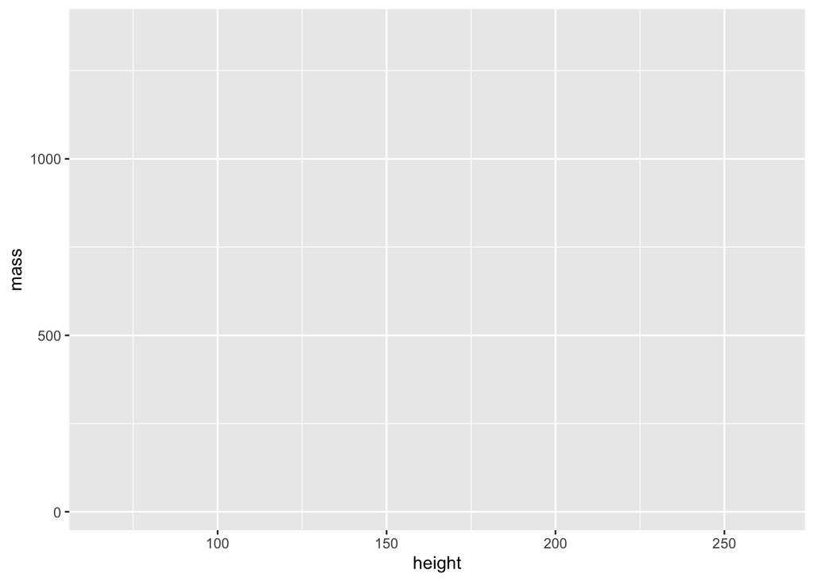

```r
ggplot(data = starwars, mapping = aes(x = height, y = mass))
```

To illustrate actual data points, add `geom_point` to the `ggplot` with `+`:

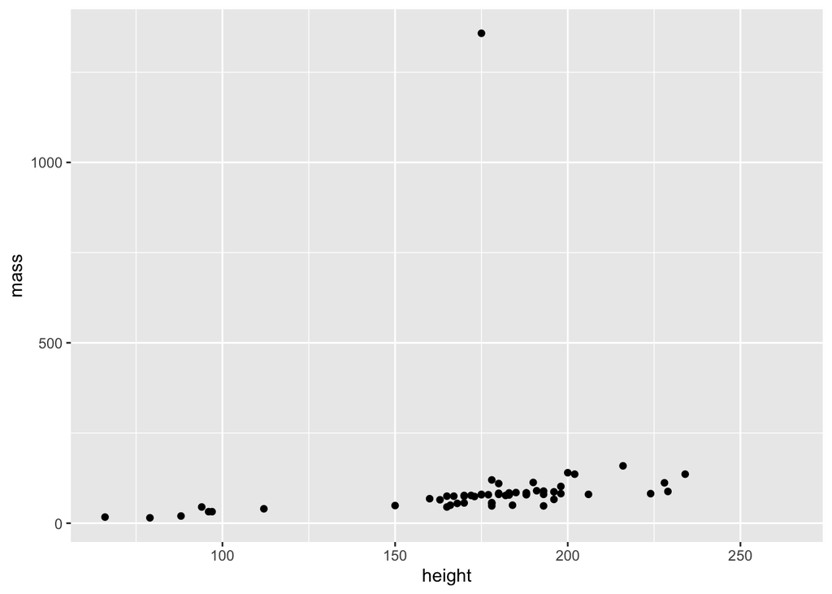

```r
ggplot(data = starwars, mapping = aes(x = height, y = mass)) +
  geom_point() #<<
```

## Labeling

To label, we use `labs` function and add it to the ggplot in the same way:

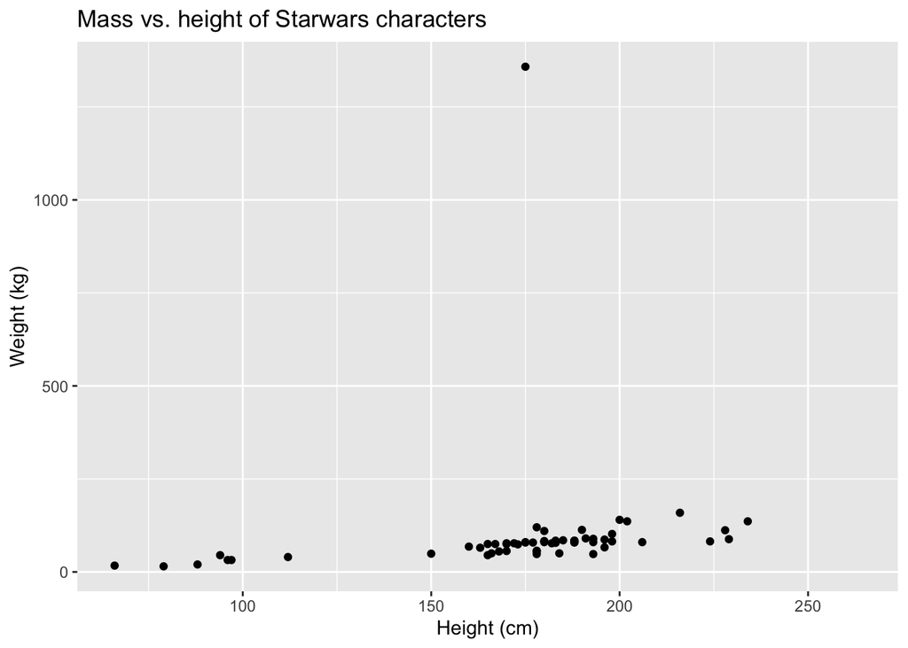

```r
ggplot(data = starwars, mapping = aes(x = height, y = mass)) +
  geom_point() +
  labs(title = "Mass vs. height of Starwars characters", #<<
       x = "Height (cm)", y = "Weight (kg)")             #<<
```

## Mass vs. height

.question[ How would you describe this relationship? What other variables would help us understand data points that don’t follow the overall trend? Who is the not so tall but really chubby character?]

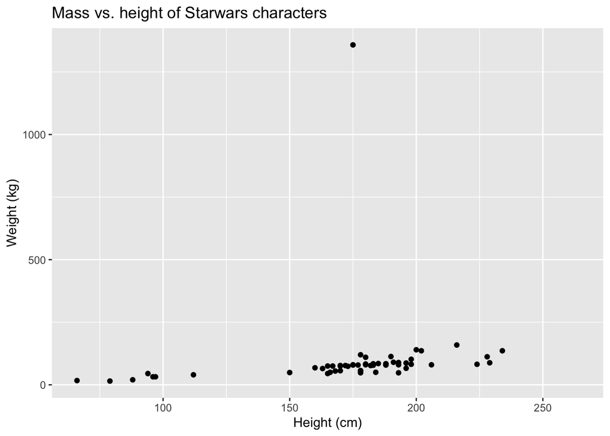

# Aesthetics

## color

You can change the color of data points using `color` option of `ggplot`. Notice that `color` is not a function but an option inside `ggplot`: it goes inside of `ggplot`, rather than outside and combined with `+` as the other functions like `geom_point` do.

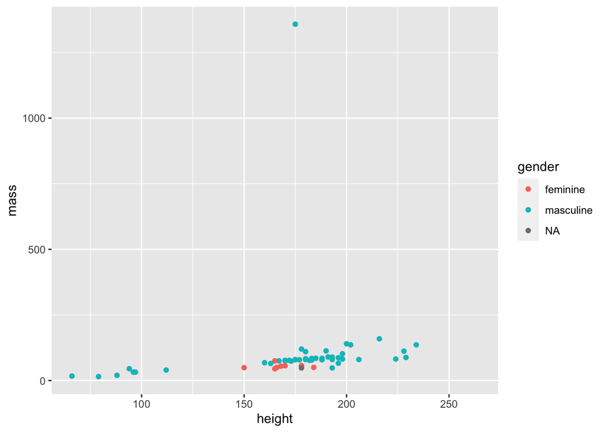

```r
ggplot(data = starwars,
       mapping = aes(x = height, y = mass,
                     color = gender)) + #<<
  geom_point()
```

If you put a continuous variable in the color option, `ggplot` uses a gradient of a color, instead of using a different color for each category.

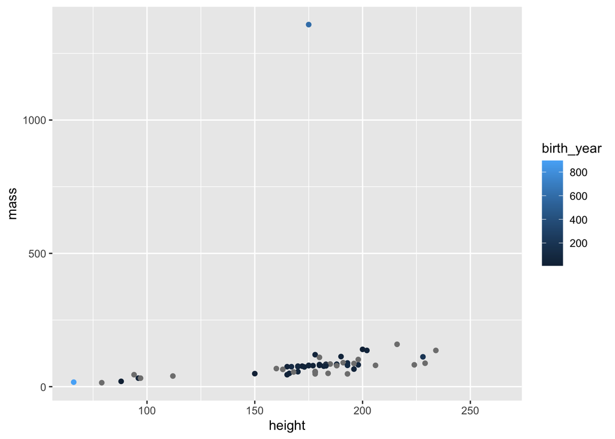

```r
ggplot(data = starwars,
       mapping = aes(x = height, y = mass,
                     color = birth_year)) + #<<
  geom_point()
```

## Size

Similarly, you can change the size using `size` option. Notice that the size changes based on the values of the variable birth_year.

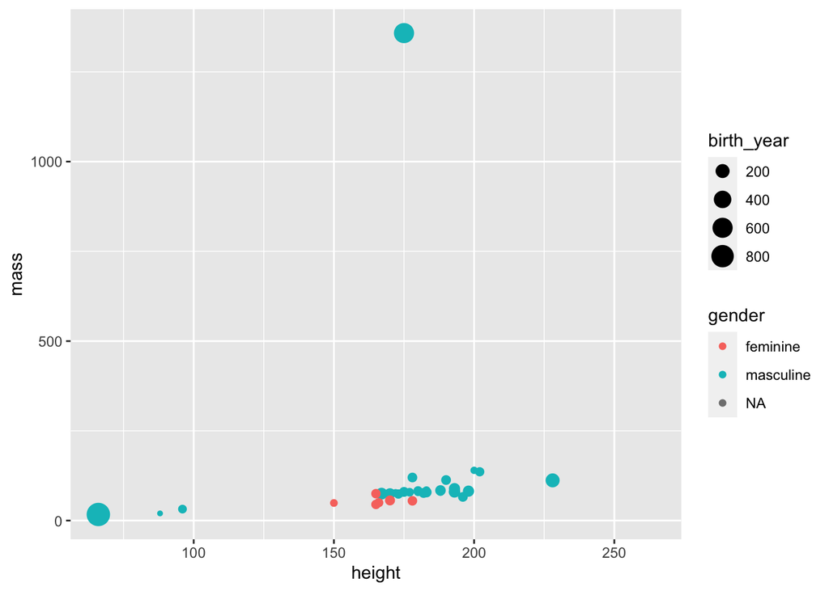

```r
ggplot(data = starwars,
       mapping = aes(x = height, y = mass,
                     color = gender,
                     size = birth_year)) + #<<
  geom_point()
```

Let’s now increase the size of all points **not** based on the values of a variable in the data:

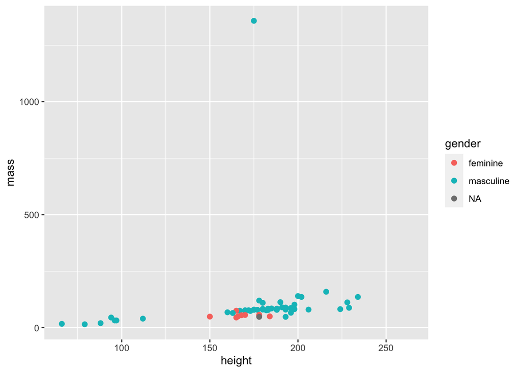

```r
ggplot(data = starwars, mapping = aes(x = height, y = mass, color = gender)) +
  geom_point(size = 2) #<<
```

## Shape

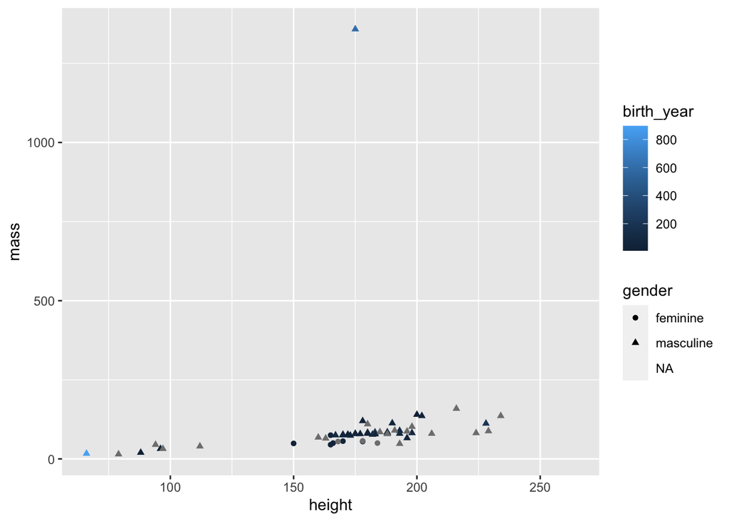

```r
ggplot(data = starwars,
       mapping = aes(x = height, y = mass,
                     color = birth_year,
                     shape = gender)) + #<<
  geom_point()
```

# Faceting

We use faceting for drawing multiple graphs for different subsets of data. You can either use `facet_grid` or `facet_wrap` depending on how you want to display. These facet functions use a special syntax below:

- `facet_grid()`: one variable per direction
  - `rows ~ cols`
  - use `.` for no faceting

## `facet_grid`

This will draw a graph for each gender and display them by column

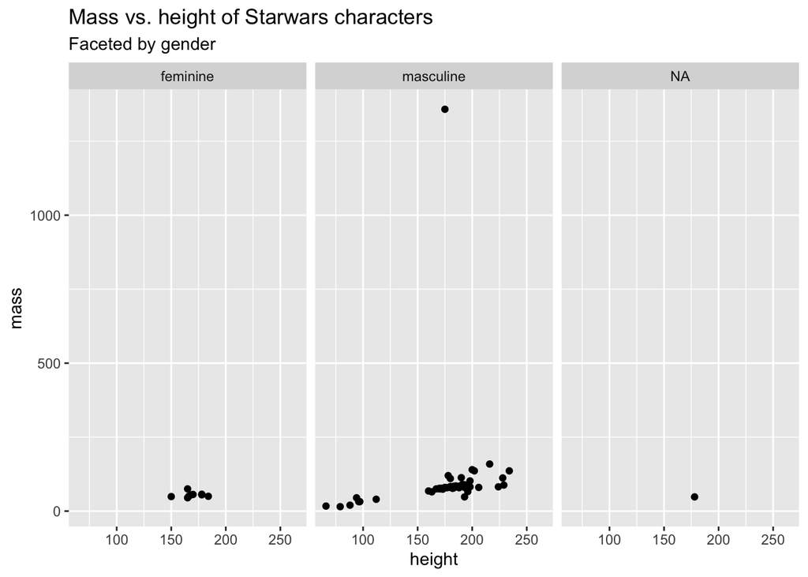

```r
ggplot(data = starwars, mapping = aes(x = height, y = mass)) +
  facet_grid(. ~ gender) + #<<
  geom_point() +
  labs(title = "Mass vs. height of Starwars characters",
       subtitle = "Faceted by gender")  #<<
```

This will draw the same but display them by row, instead of column

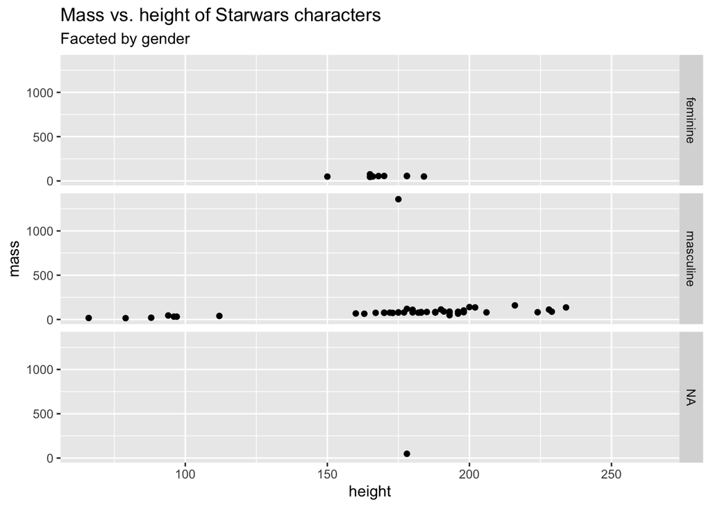

```r
ggplot(data = starwars, mapping = aes(x = height, y = mass)) +
  facet_grid(gender ~ .) + #<<
  geom_point() +
  labs(title = "Mass vs. height of Starwars characters",
       subtitle = "Faceted by gender")  #<<
```

If you put variables on the both sides of the `~`, you will see a graph for each combination of these two variables. And, depending on how you specify the order (where you put which variable on which side of `~`), you will see the display order changes. This particular example will put `gender` on row and `hair_color` on column because `gender` is on the left side of the tilde and `hair_color` is on the right side.

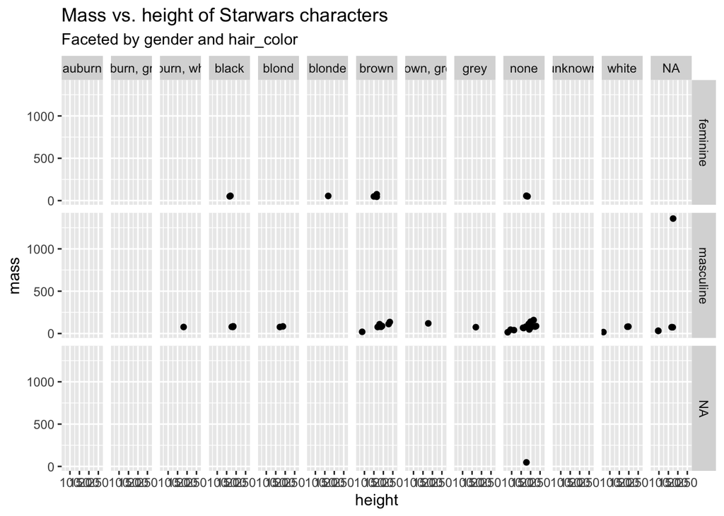

```r
ggplot(data = starwars, mapping = aes(x = height, y = mass)) +
  facet_grid(gender ~ hair_color) + #<<
  geom_point() +
  labs(title = "Mass vs. height of Starwars characters",
       subtitle = "Faceted by gender and hair_color")  #<<
```

## `facet_wrap()`: to specify the number of columns in graph

`facet_wrap` requires an additional parameter `ncol`. It’s simply to specify how many columns you want to display graphs with.

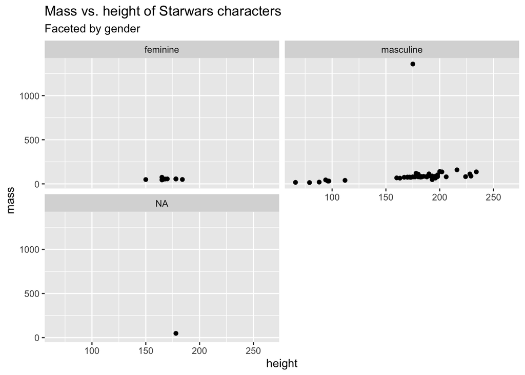

```r
ggplot(data = starwars, mapping = aes(x = height, y = mass)) +
  facet_wrap(gender ~ ., ncol=2) + #<<
  geom_point() +
  labs(title = "Mass vs. height of Starwars characters",
       subtitle = "Faceted by gender")  #<<
```

# Exercise

1. Plot a graph with `birth_year` on x-axis and `mass` on y-axis using `ggplot` and `geom_point`.

```r
# write your code below this comment line
```

2. Title the graph “Mass vs. age”

```r
# write your code below this comment line
```

3. Label x-axis as “Age” and y-axis as “Mass”

```r
# write your code below this comment line
```

4. Change the color of data points based on the value of `height`

```r
# write your code below this comment line
```

5. Change the shape of data points based on the value of `gender`

```r
# write your code below this comment line
```

6. Use `facet_grid` to draw this graph, one for each `gender` and display them by column

```r
# write your code below this comment line
```

7. Use `facet_wrap` to draw this graph, one for each `gender`, and display them with 1 column. [Hint: change `ncol` option]

```r
# write your code below this comment line
```